# Notebooks

The following tutorials and research applications refer to Jupyter notebooks provided in the repository. These notebooks can be started directly with [Binder](https://mybinder.org/v2/gh/AHartmaier/pyLabFEA.git/master)

## Tutorial 1: Introduction

In this tutorial, the basic steps of using pyLabFEA for elastic materials are demonstrated.

# Finite Element Tutorial in Python

Introduction to the Python Laboratory for Finite Element Analysis (pyLabFEA). This tutorial covers FEA with elements in one or two dimensions to evaluate the mechanical behavior of laminate geometries with linear elastic materials. See the [online documentation](https://ahartmaier.github.io/pyLabFEA/) of the pyLabFEA package for detailed information. NumPy (http://www.numpy.org) is used for mathematical operations on arrays and matplotlib (https://matplotlib.org/) for the visualization of numerical results.

Author: Alexander Hartmaier, ICAMS / Ruhr-Universität Bochum

March 2020

This work is licensed under a Creative Commons Attribution-NonCommercial-ShareAlike 4.0 International License [(CC-BY-NC-SA)](http://creativecommons.org/licenses/by-nc-sa/4.0/)

The pyLabFEA package comes with ABSOLUTELY NO WARRANTY. This is free software, and you are welcome to redistribute it under the conditions of the GNU General Public License [(GPLv3)](http://www.fsf.org/licensing/licenses/gpl.html)

## Python Laboratory for Finite Element Analysis (pyLabFEA)

In the first step, the pyLabFEA package, containing the modules pyLabFEM and pyLabMaterial, is imported.

```python
import sys
if ("../source" not in sys.path):
    sys.path.append("../source")
import pyLabFEM as FE
from pyLabMaterial import Material
```

## Model

The class `Model` is invoked to create an objecte for the finite element model to be used. This object contains all attributes of the model and defines the methods. To use the model for FEA, the following steps are performed: (i) geometry definition, (ii) material definition, (iii) applying boundary conditions, (iv) meshing, (v) solving of linear equations, and (vi) calculation of element stresses and strains by calling the corresponding methods of the class `Model`.

**Parameters:**  
dim (optional): dim=1 for 1-d model, dim=2 for 2-d model (default: dim=1)  
planestress (optional, used only in 2-d models): True if plane stress conditions shall be considered (default: planestress=False)

**Methods:**  
`geom`: define (laminate) geometry with sections  
`assign`: assign material properties to sections  
`bcleft`, `bcright`, `bctop`, `bcbot`: define boundary conditions  
`mesh`: generate mesh (1-d elements with linear or quadratic shape functions or 2-d mesh with linear quadriliteratl elements)  
`solve`: setup stiffness matrix and calculate displacements satisfying mechanical equilibrium, i.e. $f=0$ for internal nodes, for given boundary conditions  
`calc_global`: calculate global stress and strain based on displacements and residual forces of boundary nodes  
`plot`: show graphical representation of mechanical quantities mapped into deformed shape

```python
fem = FE.Model()   # create element of class Model
```

## Geometry

Define the geometry of the model with method `geom`. The geometry is subdivided into sections, representing a 1-d or 2-d laminate structure normal to the $x$-direction. The sections are given as a list with the absolute length of each section. The total length of the model is the sum of all section lengths. All lengths are given in units of 1 mm.

**Parameters:**  
sect: list with absolute length of each section in x-direction  
LY (optional): height of model in y-direction (default: LY=1)  
LZ (optional): thickness of model in z-direction (default: LZ=1)

```python
fem.geom([3, 2, 4])  # define sections in absolute lengths
```

## Materials

Material properties are given either in terms of anisotropic elastic constants $C_{11}$, $C_{12}$, $C_{44}$, or – in case of an elastically isotropic material – as Young's modulus $E$ and Poisson's ratio $\nu$. The parameters must be given with their name. The material is created by applying the class `Material`, which defines a container for the attributes and methods describing material properties and behavior. Elastic properties are defined by calling the method `elasticity` with the appropriate set of parameters.

**Class:**  
`Material`

**Methods:**  
`elasticity:` define linear elastic material either by anisoptropic or by isotropic constants. Note: One complete set of elastic parameters must be provided.  
**Paramaters:**  
C11, C12, C44 (optional): anisotropic elastic constants  
E, nu (optional): Young's modulus and Poisson's ratio (isotropic elasticity)  
one of both parameter sets must be provided

**Attributes:**  
sets internal variables for $C_{11}$, $C_{12}$, $C_{44}$, $E$ and $\nu$

```python
mat1 = Material()                    # create element of class Material
mat1.elasticity(E=200.e3, nu=0.3)    # assign isotropic elastic properties
mat2 = Material()
mat2.elasticity(E=100.e3, nu=0.3)
mat3 = Material()
mat3.elasticity(E=500.e3, nu=0.3)
print('MAT1: C11, C12, C44, E, nu', mat1.C11, mat1.C12, mat1.C44, mat1.E, mat1.nu)
print('MAT2: C11, C12, C44, E, nu', mat2.C11, mat2.C12, mat2.C44, mat2.E, mat2.nu)
print('MAT3: C11, C12, C44, E, nu', mat3.C11, mat3.C12, mat3.C44, mat3.E, mat3.nu)
```

```
MAT1: C11, C12, C44, E, nu 269230.76923076925 115384.61538461539 76923.07692307692 200000.0 0.3
MAT2: C11, C12, C44, E, nu 134615.38461538462 57692.307692307695 38461.53846153846 100000.0 0.3
MAT3: C11, C12, C44, E, nu 673076.923076923 288461.53846153844 192307.6923076923 500000.0 0.3
```

## Assigning materials to model sections

Each section has to be assigned a material, which is accomplished by calling the according method of the class `Model` with the list of materials, which must have the same shape as the list of sections in the geometry definition.

```python
fem.assign([mat1, mat2, mat3])  # assign materials to sections of model
print(fem.mat)
```

```
[<pyLabMaterial.Material object at 0x1a164b3950>, <pyLabMaterial.Material object at 0x1a164b3990>, <pyLabMaterial.Material object at 0x1a164b3a90>]
```

## Boundary Conditions

For left-hand-side and bottom nodes a displacement is given, typically $u_{\rm left}=u_{\rm bot}=0$.

The type of boundary conditions for right-hand-side and top nodes is specified as either displacement (type='disp') or force (type='force'). Value and type must be specified as parameters in this sequence.

For 1-d models only `bcleft` and `bcright` can be called.

**Method:**  
`bcleft`: set displacement for lhs node(s)  
`bcbot`: set displacement for bottom node(s), has no function for 1-d models  
**Paramaters:**  
scalar value: Displacement for boundary node(s)

**Method:**  
`bcright`: set displacement or force for rhs node(s)  
`bctop`: set displaement or force for top node(s), has no function for 1-d models  
**Paramaters:**  
scalar value: Displacement of force for boundary nodes  
bctype: string indicating type of boundary conditions: 'disp' for displacements, 'force' for forces

```python
fem.bcleft(0.)     # define displacement boundary condition on lhs node (u_x given as parameter)
fem.bcright(0.1*fem.lenx, 'disp')   # rhs node is subject to 10% strain (disp = 0.1 * length of model)
```

## Meshing

Create a structured mesh with 1-d elements or 2-d quadrilateral elements. Nodes are situated at the corners of the elements and in the middle of the edges for quadratic shape functions. The finite elements of the model are stored in a list with elements of the subclass `element` with its own attributes and methods, which are used to setup the element shape function.

**Method (class Model):**  
mesh  
**Parameters:**  
NX (optional): number of elements in x-direction (default: NX=10)  
NY (optional): number of elements in y-direction (default: NY=1), only effective for 2-d models  
SF (optional): degree of shape functions: 1=linear (default), 2=quadratic

**Subclass: `Element` (parent class: `Model`)**  
**Methods:**  
calc_Bmat: Calculate B matrix at Gauss point  
calc_Kel: calculate element stiffness matrix  
**Attributes:**  
nodes: list of nodes of this element  
Lelx, Lely: x- and y-dimensions of element  
ngp: number of Gauss points  
gpx, gpy: np.arrays of x- and y-locations of Gauss points in element  
Bmat: list of B-matrices at Gauss points  
Vel: volume of element  
Kel: element stiffness matrix  
Jac: determinant of Jacobian  
wght: weight factor for each Gauss point in integration  
Sect: Section of model in which element is located  
Mat: Pointer to class `Material` to be applied to this element  
CV: Voigt stiffness matrix of element material  
eps: average element (total) strain in Voigt notation  
sig: average element stress in Voigt notation

```python
fem.mesh(NX=9)   # create mesh
print('nodal positions: ', fem.npos.round(decimals=2))
print('nodes belonging to element #0: ', fem.element[0].nodes)
print('stiffness matrix of element #0:')
print(fem.element[0].Kel.round(decimals=2))
```

```
nodal positions:  [0. 1. 2. 3. 4. 5. 6. 7. 8. 9.]
nodes belonging to element #0:  [0, 1]
stiffness matrix of element #0:
[[ 269230.77 -269230.77]
 [-269230.77  269230.77]]
```

## Solver

The system of linear equation defined by the stiffness matrix is solved, resulting in nodal displacements fulfilling mechanical equilibrium for the given boundary conditions. The nodal forces of internal nodes are zero, forces on boundary nodes are either given as boundary conditions or are residual forces on fixed boundary nodes. If no boundary conditions are specified, the force on such boundary nodes will be zero.

After solution is completed, the following attributes of the **class `Model`** are defined.  
**Attributes:**  
u: list of nodal displacements  
f: list of nodal forces  
element[i].eps, element[i].sig: Voigt strain and stress tensor of element #i

```python
fem.solve()     # solve linear system of equations
print('nodal displacements u = ',fem.u.round(decimals=2))
print('nodal forces f = ',fem.f.round(decimals=2))
print('element strain eps = ',[element.eps[0].round(decimals=2) for element in fem.element])
print('Voigt strain tensor for element #0 = ', fem.element[0].eps.round(decimals=2))
```

```
nodal displacements u =  [0.   0.1  0.21 0.31 0.52 0.73 0.77 0.82 0.86 0.9 ]
nodal forces f =  [-28175.31      0.        0.        0.        0.       -0.       -0.
      0.       -0.    28175.31]
element strain eps =  [0.1, 0.1, 0.1, 0.21, 0.21, 0.04, 0.04, 0.04, 0.04]
Voigt strain tensor for element #0 =  [0.1 0.  0.  0.  0.  0. ]
```

## Post-processing

Calculate global stresses and strains based on displacements and residual forces on boundary nodes. Provide a graphical output of the specified field, the parameter can be either 'strain' or 'stress'. A rectangle is plotted for each element, with the color given by the specified field and a color map.

**Class `Model`**  
**Method:**  
`calc_global`: Calculate global stresses and strains based on displacements and residual forces of boundary nodes.  
**Attributes:**  
glob: Python dictionary with global strains and stresses, contains the elements:  
'ebc1', 'ebc2', 'sbc1', 'sbc2' : global strain and stress calculated from reaction forces and displacements of boundary nodes (type: float)  
'eps', 'epl', 'sig', : global strain, plastic strain, and stress tensors homogenized from element solutions (type: Voigt tensor)

**Method:**  
`plot`: Calculate stresses and strains for each element and stores them in lists assigned to model.  
**Parameters:**  
fsel: field selector, string with value 'strain1' for $\epsilon_{11}$, 'strain2' for $\epsilon_{22}$, 'stress1' for $\sigma_{11}$, 'stress2' for $\sigma_{22}$.  
mag (optional): scaling factor (magnification) for displacements (default: mag=10)  
cdepth (optional): depth of colormap (default: cdepth=20)  
showmesh (optional): Boolean variable to set/unset plotting of lines for element edges (default: showmesh=True)  
shownodes (optional): Boolean variable to set/unset plotting of nodes (default: shownodes=True)

See the [online documentation](https://ahartmaier.github.io/pyLabFEA/) of the pyLabFEA package for a full description of the attributes and methods of the class `Model`.

```
global stress: sig_11 = 28175.313 MPa
global strain: eps_11 = 10.0 %

Graphical output of model with magnification factor 10
```

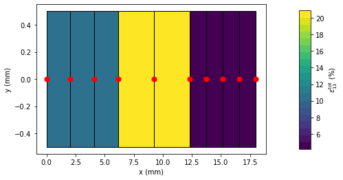

```
Graphical output of model with magnification factor 1
```

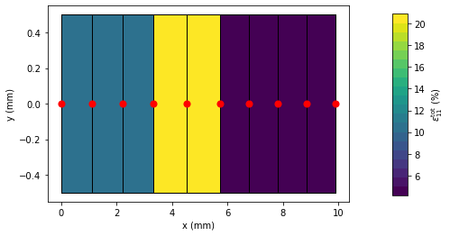

```python
fem.calc_global()   # calculate global stress and strain
print('global stress: sig_11 =',  fem.glob['sig'][0].round(decimals=3), 'MPa')
print('global strain: eps_11 =', (fem.glob['eps'][0]*100).round(decimals=2), '%')
print('\nGraphical output of model with magnification factor 10')
fem.plot('strain1') # create plot
print('\nGraphical output of model with magnification factor 1')
fem.plot('strain1', mag=1)
```

## 2-dimensional model 1: iso-strain

A 2-d model with three different sections is created and subjected to a uniaxial stress parallel to the sections (y-direction), resulting in an iso-strain condition, because all sections are subject to the same total strain as the entire model. The effective eleastic properties are calculated numerically and compared to the results of the Voigt homogenization rule (iso-strain assumption).

```
2-d Model 1: iso-strain, plane stress, eps_22=10%
Global strain:  -0.03 0.1
Element strain Section 1:  [-0.03  0.1  -0.03  0.    0.    0.  ]
Element strain Section 2:  [-0.03  0.1  -0.03  0.    0.   -0.  ]
Element strain Section 3:  [-0.03  0.1  -0.03  0.    0.   -0.  ]
Global stress (MPa):  0.0 31111.111
Element stress (MPa) Section 1:  [    0. 20000.     0.     0.     0.     0.]
Element stress (MPa) Section 2:  [    0. 10000.     0.     0.     0.    -0.]
Element stress (MPa) Section 3:  [    0. 50000.     0.     0.     0.    -0.]
Stiffness (MPa):  311111.11111111275
Target (MPa):  311111.1111111111
Error:  -5.329070518200751e-15
----------------------------------------
```

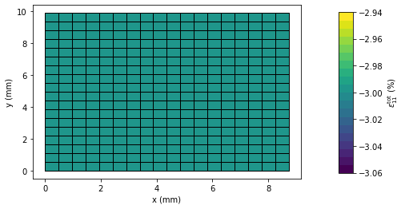

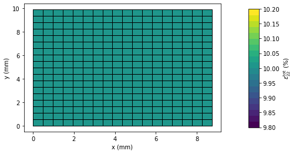

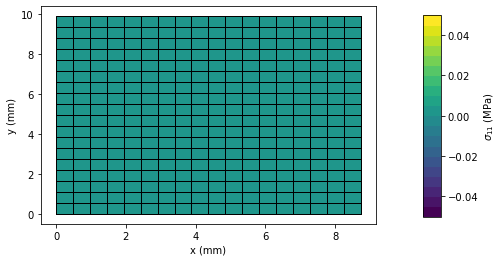

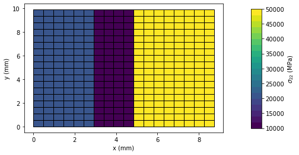

```python
'2-d model, iso-strain'
comp=FE.Model(dim=2, planestress=True)
comp.geom([3,2,4], LY=9)        # define sections in absolute lengths
comp.assign([mat1, mat2, mat3]) # assign a material to each section
comp.bcleft(0.)                 # define boundary conditions
comp.bcright(0., 'force')
comp.bcbot(0.)
comp.bctop(0.1*comp.leny, 'disp') # apply eps_22 strain at top boundary
comp.mesh(NX=18, NY=18)         # create structured mesh with 18x18 elements
comp.solve()                    # solve system of equations for mechanical equilibrium
comp.calc_global()              # evaluate global properties
mod_stiff = comp.glob['sig'][1]/comp.glob['eps'][1]
voigt_stiff = 3.*mat1.E/9 + 2*mat2.E/9 + 4*mat3.E/9 # weighted average of Young's moduli wrt volume fractions
print('2-d Model 1: iso-strain, plane stress, eps_22=10%')
print('Global strain: ',comp.glob['eps'][0].round(decimals=3), comp.glob['eps'][1].round(decimals=3))
print('Element strain Section 1: ', comp.element[0].eps.round(decimals=3))
print('Element strain Section 2: ', comp.element[6*18].eps.round(decimals=3))
print('Element strain Section 3: ', comp.element[10*18].eps.round(decimals=3))
print('Global stress (MPa): ',comp.glob['sig'][0].round(decimals=3), comp.glob['sig'][1].round(decimals=3))
print('Element stress (MPa) Section 1: ', comp.element[0].sig.round(decimals=3))
print('Element stress (MPa) Section 2: ', comp.element[6*18].sig.round(decimals=3))
print('Element stress (MPa) Section 3: ', comp.element[10*18].sig.round(decimals=3))
print('Stiffness (MPa): ',mod_stiff)
print('Target (MPa): ', voigt_stiff)
print('Error: ', 1.-mod_stiff/voigt_stiff)
print('----------------------------------------')

comp.plot('strain1', mag=1, shownodes=False)
comp.plot('strain2', mag=1, shownodes=False)
comp.plot('stress1', mag=1, shownodes=False)
comp.plot('stress2', mag=1, shownodes=False)
```

## 2-dimensional model 2: iso-stress

A 2-d model with three different sections is created and subjected to a uniaxial strain perpendicular to the sections (x-direction) resulting in an iso-stress condition, because all section are subject to the same stress in loading direction as the entire model. The effective eleastic properties are calculated numerically and compared to the results of the Reuss homogenization rule (iso-stress assumption).

```
2-d Model 2: isostress, eps_11=10%
Global strain:  0.1 0.0
Element strain Section 1:  [ 0.105 -0.     0.     0.     0.     0.   ]
Element strain Section 2:  [ 0.209 -0.     0.     0.     0.     0.   ]
Element strain Section 3:  [ 0.042  0.     0.     0.     0.    -0.   ]
Global stress:  28175.313 12075.134
Element stress (MPa) Section 1:  [28175.313 12075.134 12075.134     0.        0.        0.   ]
Element stress (MPa) Section 2:  [28175.313 12075.134 12075.134     0.        0.        0.   ]
Element stress (MPa) Section 3:  [28175.313 12075.134 12075.134     0.        0.       -0.   ]
Stiffness (MPa):  281753.13059033663
Target (MPa):  281753.1305903399
Error:  1.1546319456101628e-14
----------------------------------------
```

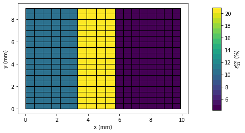

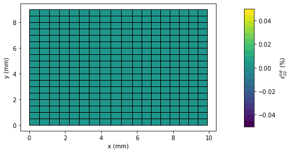

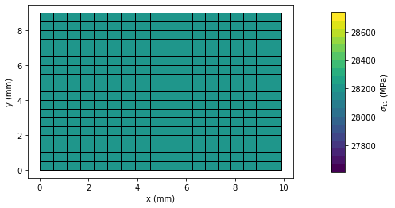

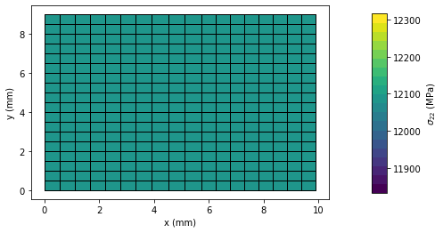

```python
'2-d model, iso-stress'
comp2=FE.Model(dim=2, planestress=False)
comp2.geom([3,2,4], LY=9)  # define sections in absolute lengths
comp2.assign([mat1, mat2, mat3])
comp2.bcleft(0.)
comp2.bcright(0.1*comp2.lenx, 'disp')
comp2.bcbot(0.)
comp2.bctop(0., 'disp')
comp2.mesh(NX=18, NY=18)
comp2.solve()
comp2.calc_global()
mod_stiff = comp2.glob['sig'][0]/comp2.glob['eps'][0]
reuss_stiff = 1./(3/(9*mat1.C11) + 2/(9*mat2.C11) + 4/(9*mat3.C11)) # Reuss average of stiffness
print('2-d Model 2: isostress, eps_11=10%')
print('Global strain: ',comp2.glob['eps'][0].round(decimals=3), comp2.glob['eps'][1].round(decimals=3))
print('Element strain Section 1: ', comp2.element[0].eps.round(decimals=3))
print('Element strain Section 2: ', comp2.element[6*18].eps.round(decimals=3))
print('Element strain Section 3: ', comp2.element[10*18].eps.round(decimals=3))
print('Global stress: ',comp2.glob['sig'][0].round(decimals=3), comp2.glob['sig'][1].round(decimals=3))
print('Element stress (MPa) Section 1: ', comp2.element[0].sig.round(decimals=3))
print('Element stress (MPa) Section 2: ', comp2.element[6*18].sig.round(decimals=3))
print('Element stress (MPa) Section 3: ', comp2.element[10*18].sig.round(decimals=3))
print('Stiffness (MPa): ',mod_stiff)
print('Target (MPa): ', reuss_stiff)
print('Error: ', 1.-mod_stiff/reuss_stiff)
print('----------------------------------------')

comp2.plot('strain1', mag=1, shownodes=False)
comp2.plot('strain2', mag=1, shownodes=False)
comp2.plot('stress1', mag=1, shownodes=False)
comp2.plot('stress2', mag=1, shownodes=False)
```

## Summary

FE models with linear elastic materials have been created and applied to analyze the mechanical response of elastic structures to given boundary conditions. The properties of linear-elastic structures are analysed more closely in the tutorial [Composites](https://ahartmaier.github.io/pyLabFEA/examples.html#tutorial-2-composites).

## Tutorial 2: Composites

In this tutorial, the properties of composites made from different elastic materials are analyzed, and the numerical solution is compared with the expected values from mechanical models.

# Micromechanics of Elastic Composites

Assess properties of linear-elastic composites by Finite Element Analysis (FEA). Model structures of laminates are created and analysed with the pyLabFEA package, see the [online documentation](https://ahartmaier.github.io/pyLabFEA/) and the tutorial [Introduction](https://ahartmaier.github.io/pyLabFEA/examples.html#tutorial-1-introduction) for detailed information on the functionality of the package. This tutorial uses the matplotlib (https://matplotlib.org/) library for the visualization of results, and NumPy (http://www.numpy.org) for mathematical operations with arrays.

Author: Alexander Hartmaier, ICAMS / Ruhr-Universität Bochum, Germany

March 2020

This work is licensed under a Creative Commons Attribution-NonCommercial-ShareAlike 4.0 International License [(CC-BY-NC-SA)](http://creativecommons.org/licenses/by-nc-sa/4.0/)

The pyLabFEA package comes with ABSOLUTELY NO WARRANTY. This is free software, and you are welcome to redistribute it under the conditions of the GNU General Public License [(GPLv3)](http://www.fsf.org/licensing/licenses/gpl.html)

## 1. Finite Element Model

In a first step, the class `Model` is invoked to generate a container for the Finite Element Model. This container stores all attributes and defines methods to be applied. On this model, the following steps are performed: (i) geometry definition, (ii) material definition, (iii) applying boundary conditions, (iv) meshing, (v) solving of linear equations, and (vi) calculation of global stresses and strains to obtain the effective stiffness of the laminate structure.

### Geometry

Define a laminate composite geometry for the model with the method `geom`. The method takes a list with the sizes of the sections of the laminate as input. Later material properties are assigned to each section.

### Materials

Linear elastic material properties are defined here in terms of Young's modulus $E$ and Poisson ratio $\nu$, by using the class `Material`. The resulting material definitions are assigned to the sections of the geometry with the `assign` method of the finite element model.

### Boundary Conditions

For the 2-d model, different boundary conditions are defined, resulting in longitudinal or transversal loading conditions with respect to the laminate structure. The first case applies a uniaxial stress parallel to the laminate sections, resulting in an iso-strain condition according to the Voigt model. For transversal loading, either uniaxial strain or uniaxial stress perpendicular to the laminate structure is applied. These boundary conditions approximate the iso-stress assumption of the Reuss model to various degrees of fulfillment.

### Meshing

The laminate model in subdivided into finite elements with nodes at their corners, by calling the method `mesh`. A mesh with 2-d quadrilateral elements with linear shape functions is created.

### Solver

By invoking the method `solve` the system of linear equation defined by the stiffness matrix is solved using the NumPy `linalg` solver, see http://www.numpy.org. This results in nodal displacements fulfilling mechanical equilibrium for the given boundary conditions, i.e. the total force on any internal node is zero. Forces on boundary nodes are either given as boundary conditions or are residual forces on fixed boundary nodes. If no boundary conditions are specified, the force on that node will be zero.

### Postprocessing

Calculate and print stresses and strains within elements, revealing the local mechanical condition in each part of the laminate. The graphics are generated with the matplotlib.pyplot libary, see https://matplotlib.org/3.1.0/tutorials/introductory/pyplot.html. Furthermore, the global stresses and strains are calculated, from which the effective stiffness of the laminate is derived.

## 2. Laminate model under isostrain conditions (Voigt model)

In the first step, a laminate model with 5 different sections in generated. The model represents a composite with with a compliant phase (Material: mat1, Young's modulus $E=10$ GPa and volume fraction 75%) and a stiff phase (material: mat2, $E=300$ GPa and volume fraction 25%). This model is subjected to a uniaxial stress longitudinal to the laminate structure to calculate the effective Young's modulus that is compared to the value obtained from the Voigt model.

```
2-d Model: isostrain, uniaxial stress, e2=10%
Global strain:  -0.03 0.1
Element strain Section 1:  [-0.03  0.1  -0.03  0.    0.    0.  ]
Element strain Section 2:  [-0.03  0.1  -0.03  0.    0.    0.  ]
Global stress:  0.0 8250.0
Element stress (MPa) Section 1:  [   0. 1000.    0.    0.    0.    0.]
Element stress (MPa) Section 2:  [    0. 30000.     0.     0.     0.     0.]
Stiffness (MPa):  82500.00000000012
Target (MPa):  82500.0
Error:  -1.3322676295501878e-15
----------------------------------------
```

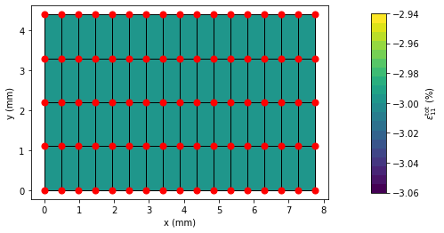

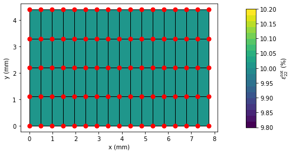

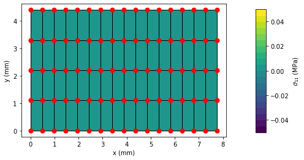

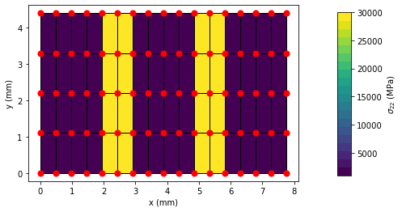

```python
import sys
if ("../source" not in sys.path):
    sys.path.append("../source")

import pyLabFEM as FE
from pyLabMaterial import Material
'laminate model is generated and elastic properties are assigned to each section'
fem_v = FE.Model(dim=2, planestress=True)   # call class to generate container for finite element model
fem_v.geom([2, 1, 2, 1, 2], LY=4.) # define sections in absolute lengths
mat1 = Material()               # call class to generate container for material
mat1.elasticity(E=10.e3, nu=0.3)   # define materials by their elastic propertiess
mat2 = Material()               # define second material
mat2.elasticity(E=300.e3, nu=0.3)
fem_v.assign([mat1, mat2, mat1, mat2, mat1])  # assign the proper material to each section
fmat1 = 6./8.   # calculate volume fraction of each material
fmat2 = 2./8.
'boundary conditions: uniaxial stress in longitudinal direction'
fem_v.bcleft(0.)                     # fix left and bottom boundary
fem_v.bcbot(0.)
fem_v.bcright(0., 'force')           # free boundary condition on right edge of model
fem_v.bctop(0.1*fem_v.leny, 'disp')  # strain applied to top nodes
'solution and evalutation of effective properties'
fem_v.mesh(NX=16, NY=4) # create mesh
fem_v.solve()           # solve system of equations
fem_v.calc_global()     # calculate global stress and strain
mod_stiff = fem_v.glob['sig'][1]/fem_v.glob['eps'][1]     # effective stiffness of numerical model
voigt_stiff = fmat1*mat1.E + fmat2*mat2.E # Voigt stiffness: weighted average of Young's moduli wrt volume fractions
print('2-d Model: isostrain, uniaxial stress, e2=10%')
print('Global strain: ',fem_v.glob['eps'][0].round(decimals=3), fem_v.glob['eps'][1].round(decimals=3))
print('Element strain Section 1: ', fem_v.element[0].eps.round(decimals=3))
print('Element strain Section 2: ', fem_v.element[16].eps.round(decimals=3))
print('Global stress: ',fem_v.glob['sig'][0].round(decimals=3), fem_v.glob['sig'][1].round(decimals=3))
print('Element stress (MPa) Section 1: ', fem_v.element[0].sig.round(decimals=3))
print('Element stress (MPa) Section 2: ', fem_v.element[16].sig.round(decimals=3))
print('Stiffness (MPa): ',mod_stiff)
print('Target (MPa): ', voigt_stiff)
print('Error: ', 1.-mod_stiff/voigt_stiff)
print('----------------------------------------')
fem_v.plot('strain1',mag=1)
fem_v.plot('strain2',mag=1)
fem_v.plot('stress1',mag=1)
fem_v.plot('stress2',mag=1)
```

It is seen that the isostrain assumption is fulfilled to a very good degree and that the numerical value is identical to that of the analytical Voigt model.

In the next step, a new model with the identical geometry and materials is generated, but subjected to transversal loading with a uniaxial strain.

```
2-d Model: isostress, uniaxial strain e1=10%
Global strain:  0.1 0.0
Element strain Section 1:  [0.132 0.    0.    0.    0.    0.   ]
Element strain Section 2:  [ 0.004  0.     0.     0.     0.    -0.   ]
Global stress:  1775.148 760.778
Element stress (MPa) Section 1:  [1775.148  760.778  760.778    0.       0.       0.   ]
Element stress (MPa) Section 2:  [1775.148  760.778  760.778    0.       0.      -0.   ]
Stiffness (MPa):  17751.479289940882
Target (MPa):  17751.479289940828
Error:  -3.1086244689504383e-15
----------------------------------------
```

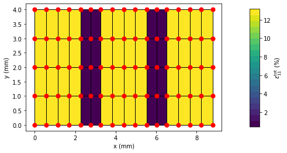

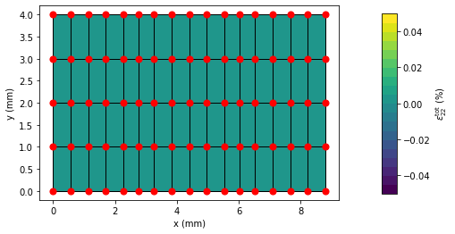

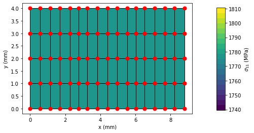

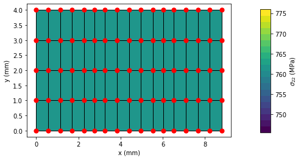

```python
'laminate model is generated and elastic properties are assigned to each section'
fem_r = FE.Model(dim=2)
fem_r.geom([2, 1, 2, 1, 2], LY=4.)            # define sections in absolute lengths
fem_r.assign([mat1, mat2, mat1, mat2, mat1])  # assign the materials to each section
fmat1 = 6./8.   # calculate volume fractions
fmat2 = 2./8.
'mechanical boundary conditions for Reuss model (isostres) with uniaxial strain'
fem_r.bcleft(0.)          # fix left and bottom boundary
fem_r.bcbot(0.)
fem_r.bcright(0.1*fem_r.lenx, 'disp')   # rhs nodes are subject to 10% strain (disp = 0.1 * length of model)
fem_r.bctop(0., 'disp')   # top boundary is fixed
'solution and evaluation of effective properties'
fem_r.mesh(NX=16, NY=4)   # create mesh
fem_r.solve()             # solve equation for mechanical equilibrium
fem_r.calc_global()       # calculate global stress and strain
mod_stiff = fem_r.glob['sig'][0]/fem_r.glob['eps'][0]              # calculate effective stiffness of model
reuss_stiff = 1./(fmat1/mat1.C11 + fmat2/mat2.C11) # Reuss average for stiffness
print('2-d Model: isostress, uniaxial strain e1=10%')
print('Global strain: ',fem_r.glob['eps'][0].round(decimals=3), fem_r.glob['eps'][1].round(decimals=3))
print('Element strain Section 1: ', fem_r.element[0].eps.round(decimals=3))
print('Element strain Section 2: ', fem_r.element[16].eps.round(decimals=3))
print('Global stress: ',fem_r.glob['sig'][0].round(decimals=3), fem_r.glob['sig'][1].round(decimals=3))
print('Element stress (MPa) Section 1: ', fem_r.element[0].sig.round(decimals=3))
print('Element stress (MPa) Section 2: ', fem_r.element[16].sig.round(decimals=3))
print('Stiffness (MPa): ',mod_stiff)
print('Target (MPa): ', reuss_stiff)
print('Error: ', 1.-mod_stiff/reuss_stiff)
print('----------------------------------------')
fem_r.plot('strain1',mag=1)
fem_r.plot('strain2',mag=1)
fem_r.plot('stress1',mag=1)
fem_r.plot('stress2',mag=1)
```

The Reuss model is well fulfilled for uniaxial strain conditions, where the cross-contraction does not change the geometry of the model. Thus the isostress assumption is valid. Under such uniaxial strain conditions, however, the elastic stiffness $C_{11}$ is the relevant quantity and the calculated numerical value is identical to that calculated by the analytical Reuss model. Now we apply a uniaxial stress, to calculate an effective Young's modulus of the model.

```
2-d Model: uniaxial stress, e1=10%
Global strain:  0.1 -0.014
Element strain Section 1:  [ 0.138 -0.021 -0.05   0.     0.     0.001]
Element strain Section 2:  [ 0.006 -0.005 -0.     0.     0.     0.   ]
Global stress:  1387.383 0.0
Element stress (MPa) Section 1:  [1447.922  226.668    0.       0.       0.       4.562]
Element stress (MPa) Section 2:  [ 1376.046 -1043.114     0.        0.        0.       23.037]
Stiffness (MPa):  13873.83032469878
Target (MPa):  13186.813186813188
Error:  -0.05209879962299069
----------------------------------------
```

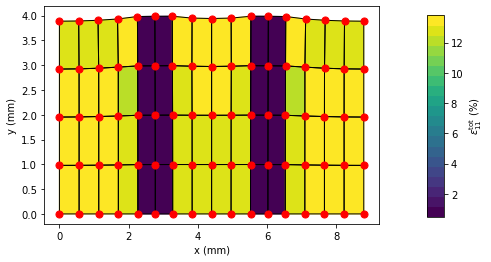

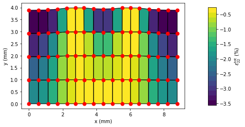

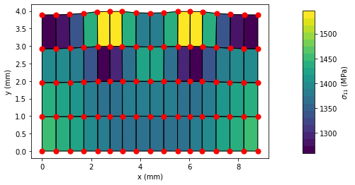

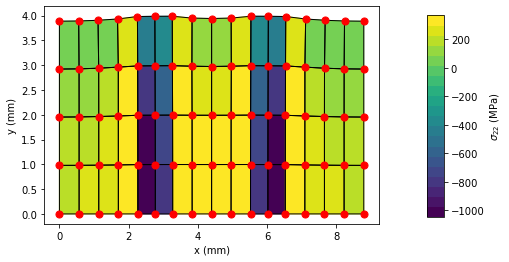

```python
'mechanical boundary conditions changed to uniaxial stress'
fem_r.bctop(0., 'force')  # top boundary is free (other boundary conditions remain in place)
fem_r.planestress = True  # plane stress condition is activated
fem_r.mesh(NX=16, NY=4)   # create mesh
'solution and evaluation of effective properties'
fem_r.solve()             # solve equation for mechanical equilibrium
fem_r.calc_global()       # calculate global stress and strain
mod_stiff = fem_r.glob['sig'][0]/fem_r.glob['eps'][0]          # calculate effective Young's modulus of model
reuss_stiff = 1./(fmat1/mat1.E + fmat2/mat2.E) # Reuss average for Young's modulus
print('2-d Model: uniaxial stress, e1=10%')
print('Global strain: ',fem_r.glob['eps'][0].round(decimals=3), fem_r.glob['eps'][1].round(decimals=3))
print('Element strain Section 1: ', fem_r.element[0].eps.round(decimals=3))
print('Element strain Section 2: ', fem_r.element[16].eps.round(decimals=3))
print('Global stress: ',fem_r.glob['sig'][0].round(decimals=3), fem_r.glob['sig'][1].round(decimals=3))
print('Element stress (MPa) Section 1: ', fem_r.element[0].sig.round(decimals=3))
print('Element stress (MPa) Section 2: ', fem_r.element[16].sig.round(decimals=3))
print('Stiffness (MPa): ',mod_stiff)
print('Target (MPa): ', reuss_stiff)
print('Error: ', 1.-mod_stiff/reuss_stiff)
print('----------------------------------------')
fem_r.plot('strain1',mag=1)
fem_r.plot('strain2',mag=1)
fem_r.plot('stress1',mag=1)
fem_r.plot('stress2',mag=1)
```

Because of the different strains in both phases, their cross contraction is different, which violates the iso-stress assumption. The effective numerical Young's modulus under these conditions deviates from the Reuss value by 5%.

## 4. Laminate model with different geometrical arrangement of phases

In the next step, we compare composites with identical volume fractions, but different geometry, with only two sections, one for each material. Uniaxial stress is applied and the effective Young's modulus in longitudinal and transversal direction is calculated and compared to the Voigt and Reuss model, respectively.

```
2-d Model: uniaxial stress, e2=10%
Global strain:  -0.03 0.1
Element strain Section 1:  [-0.03  0.1  -0.03  0.    0.   -0.  ]
Element strain Section 2:  [-0.03  0.1  -0.03  0.    0.   -0.  ]
Global stress:  -0.0 8250.0
Element stress (MPa) Section 1:  [  -0. 1000.    0.    0.    0.   -0.]
Element stress (MPa) Section 2:  [   -0. 30000.     0.     0.     0.    -0.]
Stiffness (MPa):  82499.99999999971
Target (MPa):  82500.0
Error:  3.552713678800501e-15
----------------------------------------
```

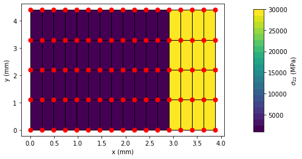

```
2-d Model: uniaxial stress, e1=10%
Global strain:  0.07 0.08
Element strain Section 1:  [ 0.108  0.069 -0.076  0.     0.     0.   ]
Element strain Section 2:  [-0.024  0.098 -0.032  0.     0.     0.   ]
Global stress:  1360.968 8249.9
Element stress (MPa) Section 1:  [1417.757 1110.813    0.       0.       0.       1.887]
Element stress (MPa) Section 2:  [1.724771e+03 2.991972e+04 0.000000e+00 0.000000e+00 0.000000e+00
 1.608600e+01]
Stiffness (MPa):  19442.402397387443
Target (MPa):  13186.813186813188
Error:  -0.47438218180188096
----------------------------------------
```

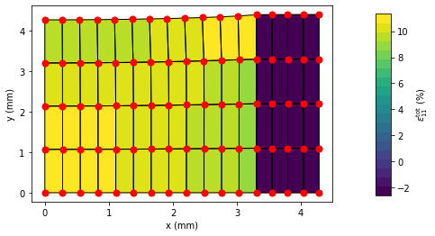

```python
fem = FE.Model(dim=2, planestress=True)
fem.geom([3, 1], LY=4)    # create block geometry
fem.assign([mat1, mat2])  # assign materials to sections
f_1 = 3/4                 # calculate volume fractions
f_2 = 1/4
'boundary conditions for Voigt model'
fem.bcleft(0.)             # fix left and bottom boundary
fem.bcbot(0.)
fem.bcright(0., 'force')   # free right edge
fem.bctop(0.1*fem.leny, 'disp')  # strain applied to top nodes
'solution and evalutation of effective properties'
fem.mesh(NX=16, NY=4)      # create mesh
fem.solve()                # calculate solution
fem.calc_global()          # calculate global stress and strain
mod_stiff = fem.glob['sig'][1]/fem.glob['eps'][1]     # effective Young's modulus of model
voigt_stiff = f_1*mat1.E + f_2*mat2.E # weighted average of Young's moduli wrt volume fractions
print('2-d Model: uniaxial stress, e2=10%')
print('Global strain: ',fem.glob['eps'][0].round(decimals=3), fem.glob['eps'][1].round(decimals=3))
print('Element strain Section 1: ', fem.element[0].eps.round(decimals=3))
print('Element strain Section 2: ', fem.element[fem.Nel-1].eps.round(decimals=3))
print('Global stress: ',fem.glob['sig'][0].round(decimals=3), fem.glob['sig'][1].round(decimals=3))
print('Element stress (MPa) Section 1: ', fem.element[0].sig.round(decimals=3))
print('Element stress (MPa) Section 2: ', fem.element[fem.Nel-1].sig.round(decimals=3))
print('Stiffness (MPa): ',mod_stiff)
print('Target (MPa): ', voigt_stiff)
print('Error: ', 1.-mod_stiff/voigt_stiff)
print('----------------------------------------')
fem.plot('stress2',mag=1)
'boundary conditions for Reuss model'
fem.bctop(0., 'force')             # free top edge
fem.bcright(0.1*fem.lenx, 'disp')  # strain applied to rhs nodes
'solution and evalutation of effective properties'
fem.solve()
fem.calc_global()
mod_stiff = fem.glob['sig'][0]/fem.glob['eps'][0]
reuss_stiff = 1/(f_1/mat1.E + f_2/mat2.E) # weighted average of Young's moduli wrt volume fractions
print('2-d Model: uniaxial stress, e1=10%')
print('Global strain: ',fem.glob['eps'][0].round(decimals=3), fem.glob['eps'][1].round(decimals=3))
print('Element strain Section 1: ', fem.element[0].eps.round(decimals=3))
print('Element strain Section 2: ', fem.element[fem.Nel-1].eps.round(decimals=3))
print('Global stress: ',fem.glob['sig'][0].round(decimals=3), fem.glob['sig'][1].round(decimals=3))
print('Element stress (MPa) Section 1: ', fem.element[0].sig.round(decimals=3))
print('Element stress (MPa) Section 2: ', fem.element[fem.Nel-1].sig.round(decimals=3))
print('Stiffness (MPa): ',mod_stiff)
print('Target (MPa): ', reuss_stiff)
print('Error: ', 1.-mod_stiff/reuss_stiff)
print('----------------------------------------')
fem.plot('strain1',mag=1)
```

## 5. Calculation of effective properties as function of volume fraction

The block-like structure is used to calculate the effective elastic properties of the composite as function of the volume fraction.

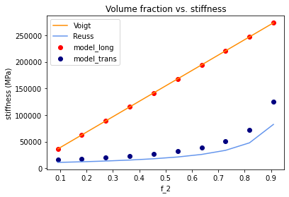

```python
import numpy as np
import matplotlib.pyplot as plt

'initialize arrays for results'
nmax = 10
f_2 = np.zeros(nmax)
E_long  = np.zeros(nmax)
E_trans = np.zeros(nmax)
E_voigt = np.zeros(nmax)
E_reuss = np.zeros(nmax)
for i in range(nmax):
    x = (i+1)/(nmax+1)
    fem.geom([x, 1.-x])
    fem.assign([mat2, mat1])
    f_2[i] = x
    'boundary conditions for Voigt model'
    fem.bcright(0., 'force')   # free right edge
    fem.bctop(0.1*fem.leny, 'disp')  # strain applied to top nodes
    'solution and evalutation of effective properties'
    fem.mesh(NX=nmax*2, NY=4)   # remeshing due to plane stress condition
    fem.solve()
    fem.calc_global()
    E_long[i] = fem.glob['sig'][1]/fem.glob['eps'][1]
    E_voigt[i] = (1-x)*mat1.E + x*mat2.E
    'boundary conditions for Reuss model'
    fem.bcright(0.1*fem.lenx, 'disp')   # strain applied to right edge
    fem.bctop(0., 'force')  # free top nodes
    'solution and evalutation of effective properties'
    fem.solve()
    fem.calc_global()
    E_trans[i] = fem.glob['sig'][0]/fem.glob['eps'][0]
    E_reuss[i] = 1./((1-x)/mat1.E + x/mat2.E)

'Graphical output'
plt.scatter(f_2,E_long,color='red', label='model_long')
plt.scatter(f_2,E_trans,color='navy', label='model_trans')
plt.plot(f_2,E_voigt,color='darkorange', label='Voigt')
plt.plot(f_2,E_reuss,color='cornflowerblue', label='Reuss')
plt.xlabel('f_2')
plt.ylabel('stiffness (MPa)')
plt.title('Volume fraction vs. stiffness')
plt.legend()
plt.show()
```

## Tutorial 3: Plasticity

Non-linear material behavior in form of plasticity is introduced in this tutorial.

# Non-linear FEA for Elastic-Plastic Materials

Plastic deformation of materials and structures can be described by non-linear Finite Element Analysis with the pyLabFEA package, see the [online documentation](https://ahartmaier.github.io/pyLabFEA/) and the tutorial [Introduction](https://ahartmaier.github.io/pyLabFEA/examples.html#tutorial-1-introduction) for detailed information on the functionality of the package. This tutorial uses the matplotlib (https://matplotlib.org/) library for the visualization of results.

Author: Alexander Hartmaier, ICAMS / Ruhr-Universität Bochum, Germany

March 2020

This work is licensed under a Creative Commons Attribution-NonCommercial-ShareAlike 4.0 International License [(CC-BY-NC-SA)](http://creativecommons.org/licenses/by-nc-sa/4.0/)

The pyLabFEA package comes with ABSOLUTELY NO WARRANTY. This is free software, and you are welcome to redistribute it under the conditions of the GNU General Public License [(GPLv3)](http://www.fsf.org/licensing/licenses/gpl.html)

```python
import sys
if ("../source" not in sys.path):
    sys.path.append("../source")

import pyLabFEM as FE
from pyLabMaterial import Material
import matplotlib.pyplot as plt
```

## 1. Define plastic material

In a first step, the class `Material` is invoked to define an elastic-plastic material. We start with the easiest case: an isotropic material with ideal plasticity, i.e. no work hardening, is defined. The class `Material` contains methods to assign elastic and plastic properties to the material, see the online documentation for a complete overview on all attributes and methods of the pyLabFEA package. All stresses are given in units of 1 MPa.

```python
'define elastic-plastic material with isotropic elastic and plastic properties and zero work hardening rate'
E  = 200.e3  # standard values for elastic and plastic properties
nu = 0.3
sy = 300.
mat1 = Material(name="isotropic, ideal plastic") # call class to generate object for material
mat1.elasticity(E=E, nu=nu)        # define material with isotropic elasticity
mat1.plasticity(sy=sy, khard=0.)   # define material with ideal isotropic plasticity
```

The class material also includes several methods to characterize the material's properties and to generate graphical output. This includes the visualization of the material's yield locus with the method `plot_yield_locus`, which displays the yield locus as the hyperplane in the principal stress space where the yield function takes the value of zero. The yield function is given as \begin{equation} f = \sigma_{eq} - \sigma_y\,, \end{equation} with the initial yield strength of the material $\sigma_y$, and the equivalent stress

\begin{equation} \sigma^\mathrm{J2}_{eq} = \sqrt{ \frac{1}{2}\left[ \left(\sigma_1-\sigma_2\right)^2 + \left(\sigma_2-\sigma_3\right)^2 + \left(\sigma_3-\sigma_1\right)^2 \right] } , \end{equation}

which - in this formulation - is based on the pricipal stresses $\sigma_i$ with $i=1, 2, 3$. This equivalent stress follows the definition of von Mises, based on J2, the second invarient of the stress deviator. If the material is exposed to a stress lying within the yield locus, i.e. a stress that produces a negative value of the yield function, the material will respond with a purely elastic deformation. If the stress reaches the yield locus, resulting in a value of zero for the yield function, plastic deformation will set in.

Since we only consider 2D models in this tutorial, the yield locus is drawn in the $\sigma_1$-$\sigma_2$ space, and $\sigma_3=0$.

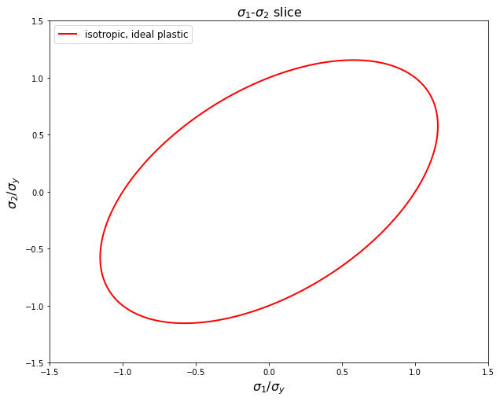

```python
'Plot yield locus'
mat1.plot_yield_locus(xstart=-1.5, xend=1.5)
```

It is seen that the typical von Mises-ellipsis is obtained, which is characteristic for isotropic plasticity.

Since the material does not sustain stresses outside the yield locus, plastic flow must occur in a way to keep the stress on the yield locus. Numerically, this is achieved by testing whether an elastic predictor step produces a stress outside the yield locus, i.e., with a positive yield function. If this is the case, a plastic strain increment must be calculated that leads again to an accepted stress state on the yield locus. The return mapping algorithm to calculate such strain increments has been described in many text books on continuum plasticity; the implementation in pyLabFEA follows the book of De Borst, Crisfield, Remmers, and Verhoosel "Nonlinear finite element analysis of solids and structures" (John Wiley & Sons, 2012). According to the Prandtl-Reuss flow rule, the plastic strain increment for a given time step can be calculated as

\begin{equation} \label{eq_epr} \dot\epsilon_{pl} = \dot{\lambda} \frac{\partial f}{\partial \sigma}= \dot{\lambda}{n} \, , \end{equation}

where ${n}$ is the normal vector to the yield locus, defined by the gradient of the yield function $\partial f/\partial \sigma_i$ ($i=1,2,3)$, and $\dot{\lambda}>0$ is the so-called plastic strain multiplier that can be evaluated as

\begin{equation} \dot{\lambda} = \frac{{n} \cdot {C}{\dot{\epsilon}}}{{n} \cdot {C} {n}} \, , \end{equation}

where $\dot{\epsilon}$ is the total strain increment of the FEA predictor step that leads to a stress state outside the yield locus and which is consequently decomposed into the plastic strain increment and the elastic strain increment - or stress increment - given by

\begin{equation} \dot{\sigma} = {C}_t \dot{\epsilon} \end{equation}

with the tangent stiffness tensor

\begin{equation} {C}_t = {C} - \frac{{C} {n} \otimes {C} {n}} {{n} \cdot {C} {n}} \end{equation}

where '$\otimes$' denotes the tensorial product in the form $a_i \otimes b_j = a_i b_j$.

The method `calc_properties` can be invoked to evaluate the flow behavior of the defined material under different load cases: (i) uniaxial stress in horizontal direction, (ii) uniaxial stress in vertical direction, (iii) equibiaxial strain under plane stress conditions, and (iv) pure shear under plane stress conditions. This is achieved by internally calling a finite element simulation to apply these load cases to the material. To plot the obtained stress-strain curves, the method `plot_stress_strain` is called, which also produces a text output.

```
---------------------------------------------------------
J2 yield stress under uniax-x loading: 300.0 MPa
---------------------------------------------------------
J2 yield stress under uniax-y loading: 300.0 MPa
---------------------------------------------------------
J2 yield stress under equibiax loading: 300.0 MPa
---------------------------------------------------------
J2 yield stress under shear loading: 300.0 MPa
---------------------------------------------------------
```

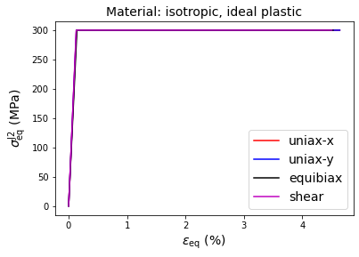

```python
'Calculate and plot stress strain curves of materials'
mat1.calc_properties(eps=0.05, sigeps=True) # calculate the stress-strain curves up to a total strain of 5%
mat1.plot_stress_strain()
```

As expected for an isotropic material, all load cases result in the same stress-strain curve, when plotted as equivalent stress vs. equivalent strain.

## 2. Work hardening

In the next step, two more materials will be defined, with identical elastic properties and identical yield strength as the first material, but with different work hardening behavior, as seen in the stress-strain curves.

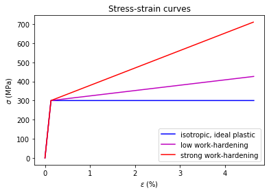

```python
'Define two more materials with different work-hardening rates'
mat2 = Material(name="low work-hardening")    # define second material
mat2.elasticity(E=200.e3, nu=0.3)             # identic elastic properties as mat1
mat2.plasticity(sy=300., khard=10.e3)         # ssame yield strength as mat1, low w.h. coefficient
mat3 = Material(name="strong work-hardening") # define third material
mat3.elasticity(E=200.e3, nu=0.3)             # identic elastic properties as mat1
mat3.plasticity(sy=300., khard=30.e3)         # same yield strength as mat1 and mat2, high w.h. coefficient
mat2.calc_properties(verb=False, eps=0.05, sigeps=True)
mat3.calc_properties(verb=False, eps=0.05, sigeps=True)

plt.plot(mat1.prop['stx']['eeq']*100., mat1.prop['stx']['seq'], '-b')
plt.plot(mat2.prop['stx']['eeq']*100., mat2.prop['stx']['seq'], '-m')
plt.plot(mat3.prop['stx']['eeq']*100., mat3.prop['stx']['seq'], '-r')
plt.title('Stress-strain curves')
plt.xlabel(r'$\epsilon$ (%)')
plt.ylabel(r'$\sigma$ (MPa)')
plt.legend([mat1.name, mat2.name, mat3.name], loc='lower right')
plt.show()
```